# Project: Investigate 'No Show for Appointments' Dataset

- Introduction
- Data Wrangling
- Exploratory Data Analysis

* Showing Stats for Patients' Data

- General Stats
- Date and Time Stats
- Date and Time Stats
- Sociodemographic's Data Stats
- Medical History Stats
- Relationships and Correlations Stats
- Conclusions

## Introduction

The current dataset was obtained from Kaggle, it represents more than one hundred thousand entries for medical appointments in Brazil. The dataset contains information regarding the patient's ID, appointment date and time, hospital location, whether the patient is enrolled in the Brazilian welfare program Bolsa Familia, chronic diseases the patient has, and whether or not the patient showed up to their appointment.

The report focuses on the prevalence of not showing up for medical appointments in Brazil, according to the included data set, and factors that are key predictors for patients to show up or not for their medical appointments.

## Research Questions

Depending on the primary exploration and visualization of data, a few questions were suggested for the purpose of generating the current investigative report. Questions are as follows:

1. Are scheduling or appointment time or date a determinant for not showing up for appointments in Brazil?
2. Are socio-demographic characteristics a determinant for not showing up for appointments in Brazil?
3. Are medical history a determinant for not showing up for appointments in Brazil?
4. Is receiving a reminder SMS for appointments a determinant for showing up for appointments in Brazil?
5. Is there a comination of factors cosidered a stronf determinant for not showing up for appointments in Brazil?

```python
# Importing the required libraries.
import numpy as np
import pandas as pd
import matplotlib.pyplot as plt
import seaborn as sns
from scipy.stats import ttest_ind
%matplotlib inline

sns.set_theme(style="whitegrid") # Setting allover plots' theme.
```

## Data Wrangling

### General Properties

```python
# Loading data and displaying the first 5 rows.
df = pd.read_csv('noshowappointments-kagglev2-may-2016.csv')
df.head()
```

|  | PatientId | AppointmentID | Gender | ScheduledDay | AppointmentDay | Age | Neighbourhood | Scholarship | Hipertension | Diabetes | Alcoholism | Handcap | SMS_received | No-show |
| --- | --- | --- | --- | --- | --- | --- | --- | --- | --- | --- | --- | --- | --- | --- |
| 0 | 2.987250e+13 | 5642903 | F | 2016-04-29T18:38:08Z | 2016-04-29T00:00:00Z | 62 | JARDIM DA PENHA | 0 | 1 | 0 | 0 | 0 | 0 | No |
| 1 | 5.589978e+14 | 5642503 | M | 2016-04-29T16:08:27Z | 2016-04-29T00:00:00Z | 56 | JARDIM DA PENHA | 0 | 0 | 0 | 0 | 0 | 0 | No |
| 2 | 4.262962e+12 | 5642549 | F | 2016-04-29T16:19:04Z | 2016-04-29T00:00:00Z | 62 | MATA DA PRAIA | 0 | 0 | 0 | 0 | 0 | 0 | No |
| 3 | 8.679512e+11 | 5642828 | F | 2016-04-29T17:29:31Z | 2016-04-29T00:00:00Z | 8 | PONTAL DE CAMBURI | 0 | 0 | 0 | 0 | 0 | 0 | No |
| 4 | 8.841186e+12 | 5642494 | F | 2016-04-29T16:07:23Z | 2016-04-29T00:00:00Z | 56 | JARDIM DA PENHA | 0 | 1 | 1 | 0 | 0 | 0 | No |

```python
# Identifying the rows and columns' count.
df.shape
```

```
(110527, 14)
```

The data frame shows 14 different columns of information for the 110,527 appointments' entries.

```python
# Checking for duplicated entries in the AppointmentID column.
df.duplicated('AppointmentID').sum()
```

```
0
```

Data shows that AppointmentID has no duplicated entries, meaning that all entries are unique. AppointmentID column would not be useful to aggregate results from, but could be used as an index for the dataset.

Data frame needs more investigation regarding duplications.

```python
# Checking for duplicated entries in the PatientId column.
df.duplicated('PatientId').sum(), df.duplicated(['PatientId','ScheduledDay']).sum()
```

```
(48228, 1334)
```

The data set has 48,228 duplicated patient ID, that could be duplicated booking for the same appointment or different appointments for the same patient. To make sure its not duplicated, another investigation by adding the ScheduleDay column to the filter, it shows 1,334 duplicated for both columns. This results require further investigation.

```python
# Creating a list without AppointmentID column from the dataset.
data_list = ['PatientId', 'Gender', 'ScheduledDay',
             'AppointmentDay', 'Age', 'Neighbourhood',
             'Scholarship', 'Hipertension', 'Diabetes',
             'Alcoholism', 'Handcap', 'SMS_received', 'No-show']

# Checking for individual duplicated entries in data frame without the AppointmentID column.
df.duplicated(data_list).sum()
```

```
618
```

The data set shows 618 duplicated entries. After removing the AppointmentID column, it appears that there are 618 duplicated entries with identical data for PatientID, ScheduledDay and AppointmentDay that could be one of two things; 1) either it's a system glitch, booking the same appointment for the same patient in the exact same time (but with different consequent Appointment ID), or 2) the patient has booked two different services on the exact same time on a single appointment (like booking two different clinics at the same time, or booking an extra laboratory or pharmacy appointment ... etc.).

Knowing that this information is not currently available and possibly hard to find, all entries for the current data set will be preserved for the purpose of the current investigative report (as each entry has a unique AppointmentID).

```python
# Showing more collective information for the data frame.
df.describe()
```

|  | PatientId | AppointmentID | Age | Scholarship | Hipertension | Diabetes | Alcoholism | Handcap | SMS_received |
| --- | --- | --- | --- | --- | --- | --- | --- | --- | --- |
| count | 1.105270e+05 | 1.105270e+05 | 110527.000000 | 110527.000000 | 110527.000000 | 110527.000000 | 110527.000000 | 110527.000000 | 110527.000000 |
| mean | 1.474963e+14 | 5.675305e+06 | 37.088874 | 0.098266 | 0.197246 | 0.071865 | 0.030400 | 0.022248 | 0.321026 |
| std | 2.560949e+14 | 7.129575e+04 | 23.110205 | 0.297675 | 0.397921 | 0.258265 | 0.171686 | 0.161543 | 0.466873 |
| min | 3.921784e+04 | 5.030230e+06 | -1.000000 | 0.000000 | 0.000000 | 0.000000 | 0.000000 | 0.000000 | 0.000000 |
| 25% | 4.172614e+12 | 5.640286e+06 | 18.000000 | 0.000000 | 0.000000 | 0.000000 | 0.000000 | 0.000000 | 0.000000 |
| 50% | 3.173184e+13 | 5.680573e+06 | 37.000000 | 0.000000 | 0.000000 | 0.000000 | 0.000000 | 0.000000 | 0.000000 |
| 75% | 9.439172e+13 | 5.725524e+06 | 55.000000 | 0.000000 | 0.000000 | 0.000000 | 0.000000 | 0.000000 | 1.000000 |
| max | 9.999816e+14 | 5.790484e+06 | 115.000000 | 1.000000 | 1.000000 | 1.000000 | 1.000000 | 4.000000 | 1.000000 |

Data frame general description shows that age ranges between -1 and 115 years of age, considering a minus value for age is not logical, and would be removed from data frame as an valid data.

```python
# Displaying rows with age value less than 0
df[df['Age'] < 0]
```

|  | PatientId | AppointmentID | Gender | ScheduledDay | AppointmentDay | Age | Neighbourhood | Scholarship | Hipertension | Diabetes | Alcoholism | Handcap | SMS_received | No-show |
| --- | --- | --- | --- | --- | --- | --- | --- | --- | --- | --- | --- | --- | --- | --- |
| 99832 | 4.659432e+14 | 5775010 | F | 2016-06-06T08:58:13Z | 2016-06-06T00:00:00Z | -1 | ROMÃO | 0 | 0 | 0 | 0 | 0 | 0 | No |

```python
# Removing the row with age equal -1.
df.drop(index=99832, inplace= True)
```

```python
# Displaying rows with age value more than 100
df[df['Age'] >= 100]
```

|  | PatientId | AppointmentID | Gender | ScheduledDay | AppointmentDay | Age | Neighbourhood | Scholarship | Hipertension | Diabetes | Alcoholism | Handcap | SMS_received | No-show |
| --- | --- | --- | --- | --- | --- | --- | --- | --- | --- | --- | --- | --- | --- | --- |
| 58014 | 9.762948e+14 | 5651757 | F | 2016-05-03T09:14:53Z | 2016-05-03T00:00:00Z | 102 | CONQUISTA | 0 | 0 | 0 | 0 | 0 | 0 | No |
| 63912 | 3.196321e+13 | 5700278 | F | 2016-05-16T09:17:44Z | 2016-05-19T00:00:00Z | 115 | ANDORINHAS | 0 | 0 | 0 | 0 | 1 | 0 | Yes |
| 63915 | 3.196321e+13 | 5700279 | F | 2016-05-16T09:17:44Z | 2016-05-19T00:00:00Z | 115 | ANDORINHAS | 0 | 0 | 0 | 0 | 1 | 0 | Yes |
| 68127 | 3.196321e+13 | 5562812 | F | 2016-04-08T14:29:17Z | 2016-05-16T00:00:00Z | 115 | ANDORINHAS | 0 | 0 | 0 | 0 | 1 | 0 | Yes |
| 76284 | 3.196321e+13 | 5744037 | F | 2016-05-30T09:44:51Z | 2016-05-30T00:00:00Z | 115 | ANDORINHAS | 0 | 0 | 0 | 0 | 1 | 0 | No |
| 79270 | 9.739430e+12 | 5747809 | M | 2016-05-30T16:21:56Z | 2016-05-31T00:00:00Z | 100 | TABUAZEIRO | 0 | 0 | 0 | 0 | 1 | 0 | No |
| 79272 | 9.739430e+12 | 5747808 | M | 2016-05-30T16:21:56Z | 2016-05-31T00:00:00Z | 100 | TABUAZEIRO | 0 | 0 | 0 | 0 | 1 | 0 | No |
| 90372 | 2.342836e+11 | 5751563 | F | 2016-05-31T10:19:49Z | 2016-06-02T00:00:00Z | 102 | MARIA ORTIZ | 0 | 0 | 0 | 0 | 0 | 0 | No |
| 92084 | 5.578313e+13 | 5670914 | F | 2016-05-06T14:55:36Z | 2016-06-03T00:00:00Z | 100 | ANTÔNIO HONÓRIO | 0 | 0 | 0 | 0 | 0 | 1 | No |
| 97666 | 7.482346e+14 | 5717451 | F | 2016-05-19T07:57:56Z | 2016-06-03T00:00:00Z | 115 | SÃO JOSÉ | 0 | 1 | 0 | 0 | 0 | 1 | No |
| 108506 | 3.939642e+11 | 5721152 | F | 2016-05-19T15:32:09Z | 2016-06-01T00:00:00Z | 100 | MARUÍPE | 0 | 0 | 0 | 0 | 0 | 0 | No |

```python
# Displaying count of unique patient IDs with age value more than or equals to 100 years.
df[df['Age'] >= 100].value_counts(['PatientId','Age'])
```

```
PatientId     Age
3.196321e+13  115    4
9.739430e+12  100    2
2.342836e+11  102    1
3.939642e+11  100    1
5.578313e+13  100    1
7.482346e+14  115    1
9.762948e+14  102    1
dtype: int64
```

Data frame shows 11 entries of age between 100 and 115 years old. According to literature, Brazil is one of highly populated countries with big centenarians' population*. Patients with 100 years of age or older are only 7, their dedicated 11 entries will be considered as they are for the analysis.

> *Nepomuceno, M. R., & Turra, C. M. (2020). The population of centenarians in Brazil: historical estimates from 1900 to 2000. Population and Development Review, 46(4), 813-833. [doi: 10.1111/padr.12355](https://onlinelibrary.wiley.com/doi/10.1111/padr.12355)

```python
# Transforming No-show column to numerical values.
df['No-show'].replace({'No': 0, 'Yes': 1}, inplace= True)
```

```python
# Changing Scholarship, Hipertension, Diabetes, Alcoholism, SMS_received, and No-show to boolean data type.
column_to_bool = ['Scholarship', 'Hipertension',
                  'Diabetes', 'Alcoholism',
                  'SMS_received', 'No-show']

for column in column_to_bool:
    df[column] = df[column].astype('bool')

# Confirming changes.
df.dtypes
```

```
PatientId         float64
AppointmentID       int64
Gender             object
ScheduledDay       object
AppointmentDay     object
Age                 int64
Neighbourhood      object
Scholarship          bool
Hipertension         bool
Diabetes             bool
Alcoholism           bool
Handcap             int64
SMS_received         bool
No-show              bool
dtype: object
```

```python
# Converts ScheduledDay column to datetime.
df['ScheduledDay'] = pd.to_datetime(df['ScheduledDay'])

# Extracts scheduled months', days', and hours' data.
df['sch_month'] = df['ScheduledDay'].dt.month
df['sch_day'] = df['ScheduledDay'].dt.day_name()
df['sch_hour'] = df['ScheduledDay'].dt.hour
```

```python
# Converts AppointmentDay column to datetime.
df['AppointmentDay'] = pd.to_datetime(df['AppointmentDay'])

# Extracts appointment months' and days' data.
df['app_month'] = df['AppointmentDay'].dt.month
df['app_day'] = df['AppointmentDay'].dt.day_name()
```

```python
# Renaming hipertension and no-show columns.
df.rename(columns={'Hipertension': 'Hypertension',
                   'Handcap': 'Handicap',
                   'No-show':'no_show'}, inplace=True)
df.head()
```

|  | PatientId | AppointmentID | Gender | ScheduledDay | AppointmentDay | Age | Neighbourhood | Scholarship | Hypertension | Diabetes | Alcoholism | Handicap | SMS_received | no_show | sch_month | sch_day | sch_hour | app_month | app_day |
| --- | --- | --- | --- | --- | --- | --- | --- | --- | --- | --- | --- | --- | --- | --- | --- | --- | --- | --- | --- |
| 0 | 2.987250e+13 | 5642903 | F | 2016-04-29 18:38:08+00:00 | 2016-04-29 00:00:00+00:00 | 62 | JARDIM DA PENHA | False | True | False | False | 0 | False | False | 4 | Friday | 18 | 4 | Friday |
| 1 | 5.589978e+14 | 5642503 | M | 2016-04-29 16:08:27+00:00 | 2016-04-29 00:00:00+00:00 | 56 | JARDIM DA PENHA | False | False | False | False | 0 | False | False | 4 | Friday | 16 | 4 | Friday |
| 2 | 4.262962e+12 | 5642549 | F | 2016-04-29 16:19:04+00:00 | 2016-04-29 00:00:00+00:00 | 62 | MATA DA PRAIA | False | False | False | False | 0 | False | False | 4 | Friday | 16 | 4 | Friday |
| 3 | 8.679512e+11 | 5642828 | F | 2016-04-29 17:29:31+00:00 | 2016-04-29 00:00:00+00:00 | 8 | PONTAL DE CAMBURI | False | False | False | False | 0 | False | False | 4 | Friday | 17 | 4 | Friday |
| 4 | 8.841186e+12 | 5642494 | F | 2016-04-29 16:07:23+00:00 | 2016-04-29 00:00:00+00:00 | 56 | JARDIM DA PENHA | False | True | True | False | 0 | False | False | 4 | Friday | 16 | 4 | Friday |

## Exploratory Data Analysis

Data frame will be treated for each column at a time, descriptive data for gathering frequencies regarding specific item like age, gender ... etc. with the affiliated plots, then another plot and description will be generated for that specific item and its relation with the not showing up for the appointments. Later in the report, a cross relation will be considered for data frame items and not showing up for appointments to identify a possible relation.

## Showing Stats for Patients' Data

### General No Show Stats

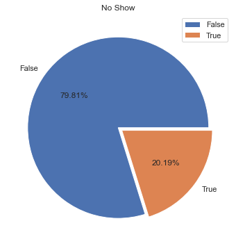

```python
# Displaying pie chart for general no show for appointments stats.
pie_noshow = df['no_show'].value_counts()
pie_noshow.plot.pie(figsize= (6,6), autopct='%.2f%%', explode=(0, .05))
plt.title('No Show')
plt.ylabel(None)
plt.legend()
plt.show()
```

Data frame shows that patients did not show up for 20.19% of all apointments.

### Date and Time Stats

```python
# Creating functions for showing figures.
def counts_figure(df, x, title, xlabel, ylabel):
    plt.figure(figsize= (15, 5))
    sns.countplot(data = df, x = x, color = None, palette= None)
    plt.title(title)
    plt.xlabel(xlabel)
    plt.ylabel(ylabel)

def relation_figure(df, x, hue, title, xlabel, ylabel):
    plt.figure(figsize= (15, 5))
    sns.countplot(data = df, x = x, hue = hue)
    plt.title(title)
    plt.xlabel(xlabel)
    plt.ylabel(ylabel)
    plt.show()
```

#### Q1. Are scheduling or appointment time or date a determinant for not showing up for appointments in Brazil?

```
5     61.00
4     22.93
6     12.44
3      3.27
2      0.25
12     0.06
1      0.05
11     0.00
Name: sch_month, dtype: float64
```

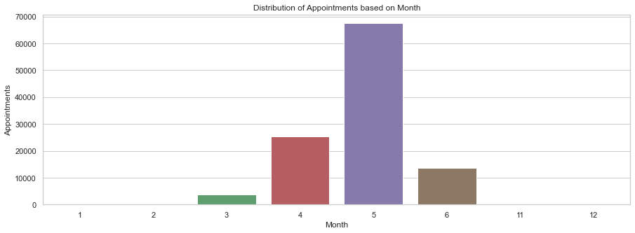

```python
# Displaying appointments count based on scheduling month.
counts_figure(df, 'sch_month', 'Distribution of Appointments based on Month',
              'Month', 'Appointments')

stats = round((df['sch_month'].value_counts() / df['PatientId'].count() * 100), 2)
stats
```

Data frame shows that May is the most scheduling month of the year, with 61.0% of all appointments booked in that month.

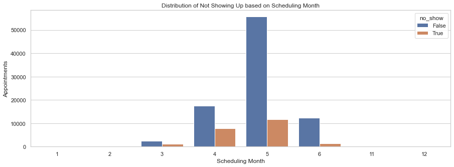

```
sch_month  no_show
11         False      100.00
6          False       89.92
5          False       82.54
2          False       70.82
1          False       70.00
4          False       69.02
12         False       68.85
3          False       66.91
           True        33.09
12         True        31.15
4          True        30.98
1          True        30.00
2          True        29.18
5          True        17.46
6          True        10.08
Name: AppointmentID, dtype: float64
```

```python
# Displaying the relationship between scheduling month and not showing up for appointments.
relation_figure(df, 'sch_month', 'no_show',
                'Distribution of Not Showing Up based on Scheduling Month',
                'Scheduling Month', 'Appointments')

counts = df.groupby(['sch_month','no_show']).count()['AppointmentID']
totals = df.groupby('sch_month').count()['AppointmentID']
proportions = counts / totals
round(proportions * 100, 2).sort_values(ascending= False)
```

```
Tuesday      23.68
Wednesday    21.95
Monday       20.89
Friday       17.11
Thursday     16.35
Saturday      0.02
Sunday        0.00
Name: sch_day, dtype: float64
```

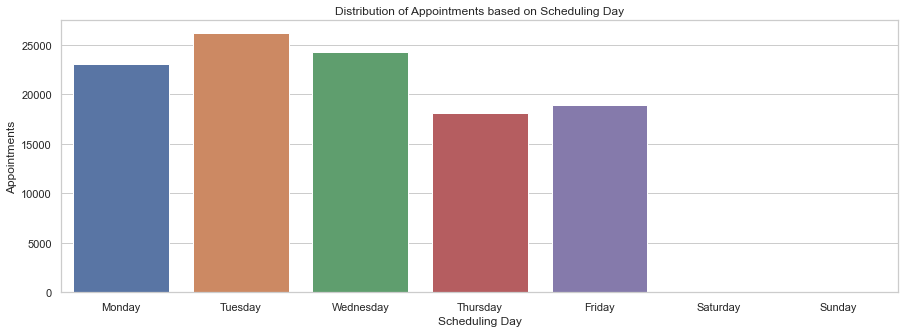

```python
# Displaying appointments count based on scheduling day.
days_list = ['Monday', 'Tuesday', 'Wednesday',
             'Thursday', 'Friday', 'Saturday', 'Sunday']
df['sch_day'] = pd.Categorical(df['sch_day'], categories=days_list, ordered=True)

counts_figure(df, df['sch_day'], 'Distribution of Appointments based on Scheduling Day',
              'Scheduling Day', 'Appointments')

stats = round((df['sch_day'].value_counts() / df['PatientId'].count() * 100), 2)
stats
```

Data frame shows that Tuesday is the most scheduling day of the week, with 23.68% of all appointments booked in that week day. In addition, saturday has the least booking rate with 0.02% of all bookings and Sunday has zero bookings.

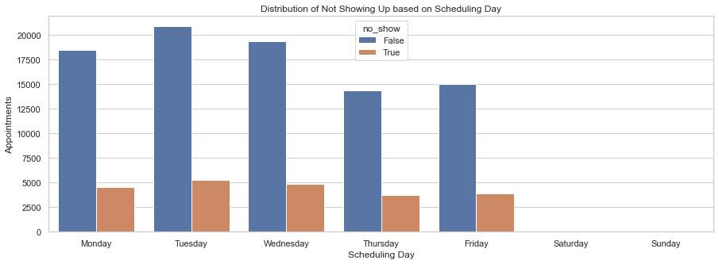

```
sch_day    no_show
Saturday   False      95.83
Monday     False      80.24
Wednesday  False      79.89
Tuesday    False      79.78
Thursday   False      79.53
Friday     False      79.45
           True       20.55
Thursday   True       20.47
Tuesday    True       20.22
Wednesday  True       20.11
Monday     True       19.76
Saturday   True        4.17
Sunday     False        NaN
           True         NaN
Name: AppointmentID, dtype: float64
```

```python
# Displaying the relationship between scheduling day and not showing up for appointments.
days_list = ['Monday', 'Tuesday', 'Wednesday',
             'Thursday', 'Friday', 'Saturday', 'Sunday']
df['sch_day'] = pd.Categorical(df['sch_day'], categories=days_list, ordered=True)

relation_figure(df, df['sch_day'], 'no_show',
                'Distribution of Not Showing Up based on Scheduling Day',
                'Scheduling Day', 'Appointments')

counts = df.groupby(['sch_day', 'no_show']).count()['AppointmentID']
totals = df.groupby(['sch_day']).count()['AppointmentID']
proportions = counts / totals
round(proportions * 100, 2).sort_values(ascending= False)
```

Data frame shows that Friday is the week day with most no show for appointment data, with 20.55% of patients have not showed up for their appointments. Also reveals that Saturday is the week day with the least amount of not showing up for appointments, with only 4.17% of patients have not showed up for their appointments.

```
7     17.38
8     13.89
9     11.60
10    10.00
14     8.26
13     8.18
11     7.66
15     7.31
16     5.01
12     4.91
17     2.63
6      1.43
18     1.21
19     0.44
20     0.09
21     0.00
Name: sch_hour, dtype: float64
```

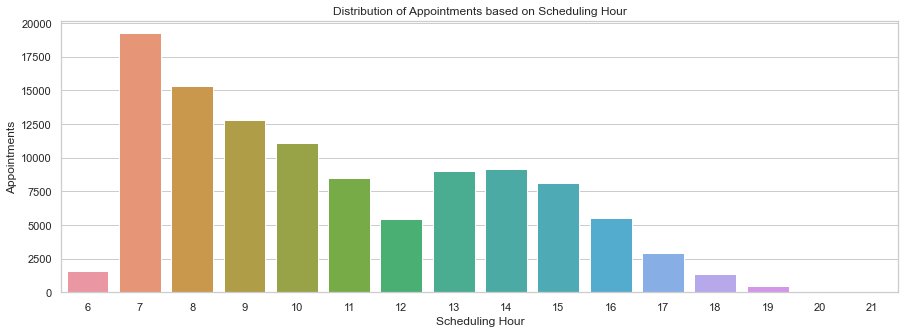

```python
# Displaying appointments count based on scheduling hour.
counts_figure(df, 'sch_hour', 'Distribution of Appointments based on Scheduling Hour',
              'Scheduling Hour', 'Appointments')

stats = round((df['sch_hour'].value_counts() / df['PatientId'].count() * 100), 2)
stats
```

Data frame shows that 07:00 AM and 08:00 AM o'clock are the most scheduling hours of the day, with 17.38%, and 13.89% of all appointments booked in that time respectively.

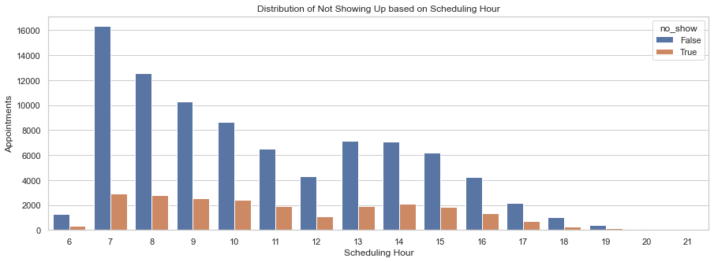

```
sch_hour  no_show
7         False      84.85
8         False      81.73
6         False      80.80
9         False      80.30
12        False      79.64
13        False      79.07
18        False      78.73
10        False      77.93
14        False      77.32
11        False      77.22
15        False      76.82
19        False      76.64
16        False      76.24
17        False      75.18
```

[output cut: 19 more lines]

```python
# Displaying the relationship between scheduling hour and not showing up for appointments.
relation_figure(df, 'sch_hour', 'no_show',
                'Distribution of Not Showing Up based on Scheduling Hour',
                'Scheduling Hour', 'Appointments')

counts = df.groupby(['sch_hour','no_show']).count()['AppointmentID']
totals = df.groupby('sch_hour').count()['AppointmentID']
proportions = counts / totals
round(proportions * 100, 2).sort_values(ascending= False)
```

Data frame shows that the hour 21:00 (09:00 PM) is the hour of the day with most no show for appointment data, with 33.33% of patients have not showed up for their appointments. Also reveals that 07:00 AM o'clock has the least amount of not showing up for appointments, with only 15.15% of patients have not showed up for their appointments.

```
5    73.14
6    23.93
4     2.93
Name: app_month, dtype: float64
```

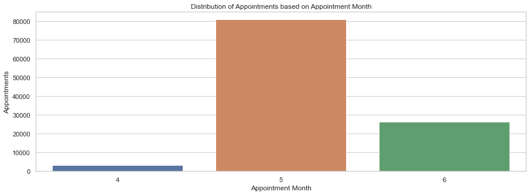

```python
# Displaying appointments count based on appointment month.
counts_figure(df, 'app_month', 'Distribution of Appointments based on Appointment Month',
              'Appointment Month', 'Appointments')

stats = round((df['app_month'].value_counts() / df['PatientId'].count() * 100), 2)
stats
```

Data frame shows that May is the most appointment month of the year, with 73.14% of all appointments booked in that month.

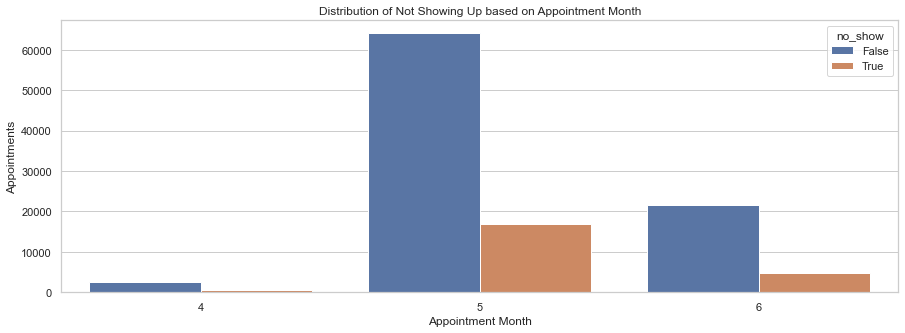

```
app_month  no_show
6          False      81.54
4          False      80.43
5          False      79.21
           True       20.79
4          True       19.57
6          True       18.46
Name: AppointmentID, dtype: float64
```

```python
# Displaying the relationship between appointment month and not showing up for appointments.
relation_figure(df, 'app_month', 'no_show',
                'Distribution of Not Showing Up based on Appointment Month',
                'Appointment Month', 'Appointments')

counts = df.groupby(['app_month','no_show']).count()['AppointmentID']
totals = df.groupby('app_month').count()['AppointmentID']
proportions = counts / totals
round(proportions * 100, 2).sort_values(ascending= False)
```

Data frame shows that May is the month with most no show for appointment data, with 20.79% of patients have not showed up for their appointments. Also reveals that June is the month with the least amount of not showing up for appointments, with only 18.46% of patients have not showed up for their appointments.

```
Wednesday    23.40
Tuesday      23.20
Monday       20.55
Friday       17.21
Thursday     15.60
Saturday      0.04
Sunday        0.00
Name: app_day, dtype: float64
```

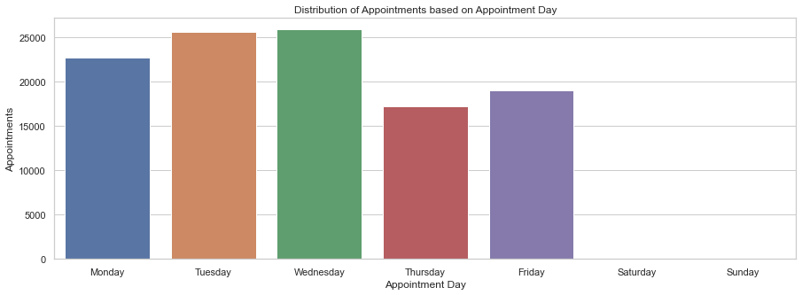

```python
# Displaying appointments count based on appointment day.
days_list = ['Monday', 'Tuesday', 'Wednesday', 'Thursday', 'Friday', 'Saturday', 'Sunday']
df['app_day'] = pd.Categorical(df['app_day'], categories=days_list, ordered=True)

counts_figure(df, df['app_day'], 'Distribution of Appointments based on Appointment Day',
              'Appointment Day', 'Appointments')

stats = round((df['app_day'].value_counts() / df['PatientId'].count() * 100), 2)
stats
```

Data frame shows that ًWednesday is the weekday with most appointments, with 23.4% of all appointments books in that weekday.

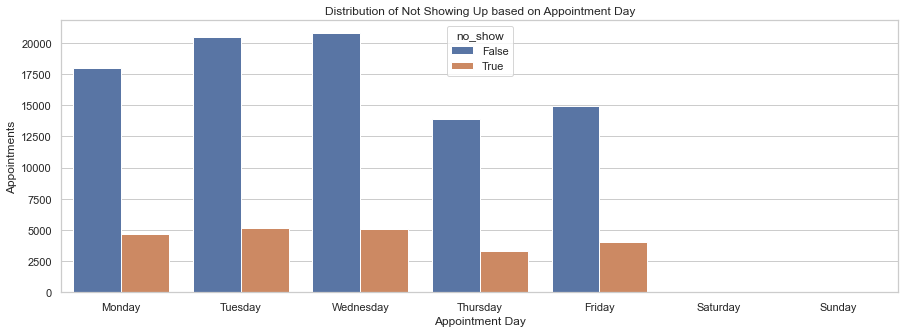

```
app_day    no_show
Thursday   False      80.65
Wednesday  False      80.31
Tuesday    False      79.91
Monday     False      79.35
Friday     False      78.77
Saturday   False      76.92
           True       23.08
Friday     True       21.23
Monday     True       20.65
Tuesday    True       20.09
Wednesday  True       19.69
Thursday   True       19.35
Sunday     False        NaN
           True         NaN
Name: AppointmentID, dtype: float64
```

```python
# Displaying the relationship between appointment day and not showing up for appointments.
relation_figure(df, 'app_day', 'no_show',
                'Distribution of Not Showing Up based on Appointment Day',
                'Appointment Day', 'Appointments')

counts = df.groupby(['app_day','no_show']).count()['AppointmentID']
totals = df.groupby('app_day').count()['AppointmentID']
proportions = counts / totals
round(proportions * 100, 2).sort_values(ascending= False)
```

Data frame shows that Saturday is the weekday with most no show for appointment data, with 23.08% of patients have not showed up for their appointments. Also reveals that Thursday is the weekday with the least amount of not showing up for appointments, with only 19.35% of patients have not showed up for their appointments.

### Sociodemographic's Data Stats

#### Q2. Are socio-demographic characteristics a determinant for not showing up for appointments in Brazil?

```
F    65.0
M    35.0
Name: Gender, dtype: float64
```

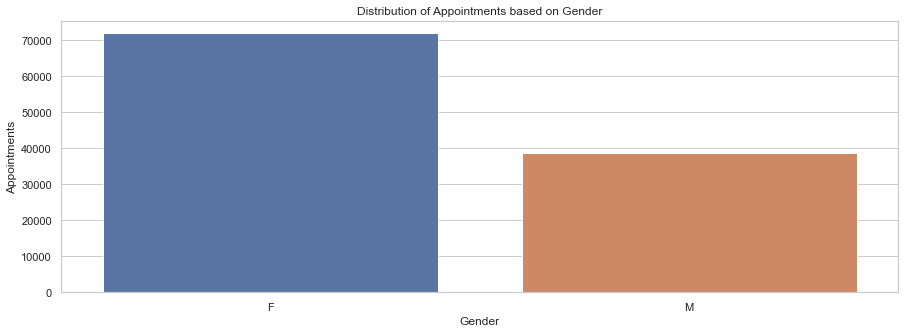

```python
# Displaying appointments count based on gender.
counts_figure(df, 'Gender', 'Distribution of Appointments based on Gender',
              'Gender', 'Appointments')

stats = round((df['Gender'].value_counts() / df['PatientId'].count() * 100), 2)
stats
```

Data frame shows that females have medical appointment more than males, 65% of all appointments booked by female patients.

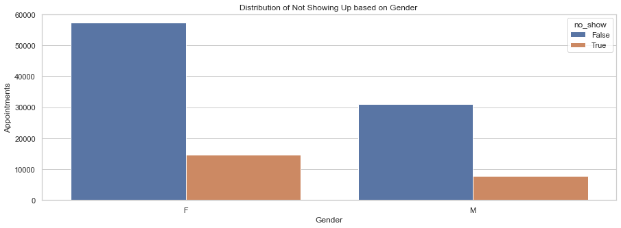

```
Gender  no_show
M       False      80.03
F       False      79.69
        True       20.31
M       True       19.97
Name: AppointmentID, dtype: float64
```

```python
# Displaying the relationship between gender and not showing up for appointments.
relation_figure(df, 'Gender', 'no_show',
                'Distribution of Not Showing Up based on Gender ',
                'Gender', 'Appointments')

counts = df.groupby(['Gender','no_show']).count()['AppointmentID']
totals = df.groupby('Gender').count()['AppointmentID']
proportions = counts / totals
round(proportions * 100, 2).sort_values(ascending= False)
```

```python
# Displaying independent smaples test relationship results
# between gender and now show data for appointments data.
group1 = df[df['Gender'] == "M"]
group2 = df[df['Gender'] == "F"]

ttest, pvalue = ttest_ind(group1['no_show'], group2['no_show'])
print('Independet samples t test = {}, significance (p value) = {}'
      .format(round(ttest, 3), round(pvalue, 3)))
```

```
Independet samples t test = -1.37, significance (p value) = 0.171
```

Data frame shows that females not showing for their appointments more than males, with 20.31% of female patients have not showed up for their appointments, while 19.97% of male patients haven't showed up for their appointments. The mean change for not showing up for appointments was not statistically signigicantly between males and females (t= 1.370, p= 0.171).

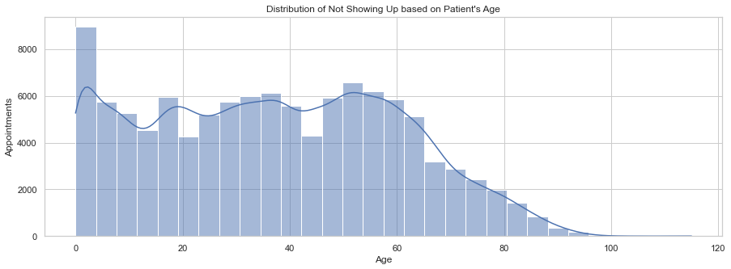

```
0     3.20
1     2.06
52    1.58
49    1.49
53    1.49
Name: Age, dtype: float64
```

```python
# Displaying appointments count based on age.
plt.figure(figsize= (15, 5))
figure = sns.histplot(data = df['Age'], bins=30, kde= True);
figure.set(xlabel = 'Age', ylabel = 'Appointments',
           title = 'Distribution of Not Showing Up based on Patient\'s Age')
plt.show()

stats = round((df['Age'].value_counts()[0:5]
               / df['PatientId'].count() * 100), 2)
stats
```

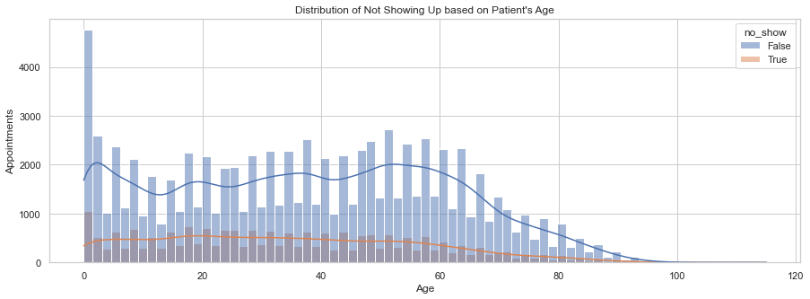

```
Age  no_show
96   True       100.00
99   False      100.00
98   True       100.00
115  False       50.00
102  False       50.00
97   True        50.00
115  True        33.33
100  False       25.00
98   False       20.00
94   True        16.67
Name: AppointmentID, dtype: float64
```

```python
# Displaying the relationship between age and not showing up for appointments.
plt.figure(figsize= (15, 5))
sns.histplot(data = df, x= 'Age', hue= 'no_show', kde= True)
plt.title('Distribution of Not Showing Up based on Patient\'s Age')
plt.xlabel('Age')
plt.ylabel('Appointments')
plt.show()

stats = round((df['sch_month']
               / df['PatientId'].count() * 100), 2)

counts = df.groupby(['Age','no_show']).size().mode()[0]
totals = df.groupby(['Age', 'no_show']).count()['AppointmentID']
proportions = counts / totals
round(proportions * 100, 2).sort_values(ascending= False).head(10)
```

- Kids sicne birth to 14 years of age
- Adolescnets from 15 to 18 years of age
- Young adults from 19 to 24 years of age
- Middle-age adults from 25 to 44 years of age
- Old adult from 45 to 64 years of age
- Youngest old from 65 to 74 years of age
- Middle old from 75 to 84 years of age
- Oldest old from 85 to 99 years of age
- Centenarians 100 years of age or older

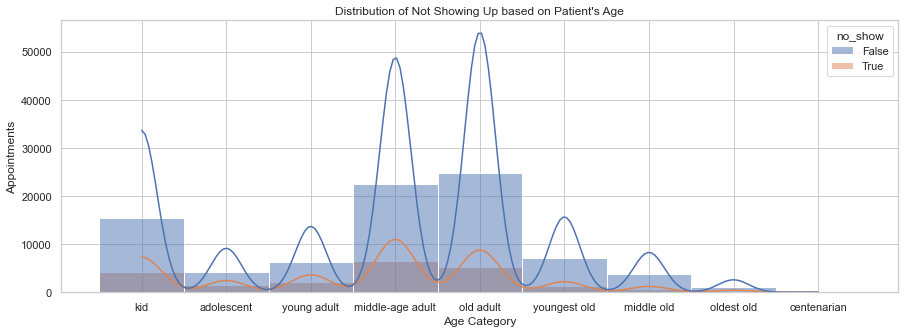

```
age_categories    no_show
youngest old      False      84.86
middle old        False      84.29
oldest old        False      83.08
old adult         False      82.80
kid               False      78.26
middle-age adult  False      77.62
young adult       False      74.78
adolescent        False      74.67
centenarian       False      72.73
                  True       27.27
adolescent        True       25.33
young adult       True       25.22
middle-age adult  True       22.38
kid               True       21.74
old adult         True       17.20
oldest old        True       16.92
middle old        True       15.71
youngest old      True       15.14
Name: AppointmentID, dtype: float64
```

```python
# Creating categories for age.
bins = [0, 14, 18, 24, 44, 64, 74, 84, 99, 120]
labels = ['kid', 'adolescent', 'young adult', 'middle-age adult', 'old adult',
          'youngest old', 'middle old', 'oldest old', 'centenarian']

df['age_categories'] = pd.cut(df['Age'], bins= bins, labels= labels)

# Displaying the relationship between age categories and not showing up for appointments.
plt.figure(figsize= (15, 5))
sns.histplot(data = df, x= 'age_categories', hue= 'no_show', kde= True)
plt.title('Distribution of Not Showing Up based on Patient\'s Age')
plt.xlabel('Age Category')
plt.ylabel('Appointments')
plt.show()

counts = df.groupby(['age_categories','no_show']).count()['AppointmentID']
totals = df.groupby('age_categories').count()['AppointmentID']
proportions = counts / totals
round(proportions * 100, 2).sort_values(ascending= False)
```

Data frame shows that centenarians (aged 100 or older) are the age category who do not show for appointments the most (27.27%), followed by adolescents (aged between 15 and 18 years of age) with 25.33% of them have not showed up for their appointments. Also reveals that youngest olds (age between 65 and 74 years of age) have the least amount of not showing up for appointments, with only 15.14% of them have not showed up for their appointments.

```
JARDIM CAMBURI     6.98
MARIA ORTIZ        5.25
RESISTÊNCIA        4.01
JARDIM DA PENHA    3.51
ITARARÉ            3.18
Name: Neighbourhood, dtype: float64
```

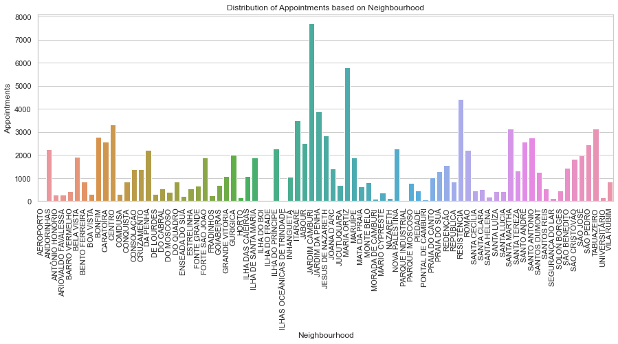

```python
# Displaying appointments count based on neighbourhood.
plt.figure(figsize= (15, 5))
sns.countplot(data = df, x = sorted(df['Neighbourhood']))
plt.xticks(rotation=90)
plt.title('Distribution of Appointments based on Neighbourhood')
plt.xlabel('Neighbourhood')
plt.ylabel('Appointments');

stats = round((df['Neighbourhood'].value_counts()[0:5]
               / df['PatientId'].count() * 100), 2)
stats
```

Data frame shows that the top five neightbourhoods according to their appointments' rate are JARDIM CAMBURI 6.98%, MARIA ORTIZ 5.25%, RESISTÊNCIA 4.01%, JARDIM DA PENHA 3.51%, and ITARARÉ 3.18%, of all appointments booked.

```
(Neighbourhood                no_show
 PARQUE INDUSTRIAL            False      100.00
 ILHAS OCEÂNICAS DE TRINDADE  True       100.00
 ILHA DO BOI                  False       91.43
 AEROPORTO                    False       87.50
 MÁRIO CYPRESTE               False       85.44
 Name: AppointmentID, dtype: float64,
 Neighbourhood  no_show
 SANTA CLARA    False      73.52
 SANTA CECÍLIA  False      72.54
 SANTOS DUMONT  False      71.08
                True       28.92
 SANTA CECÍLIA  True       27.46
 SANTA CLARA    True       26.48
 Name: AppointmentID, dtype: float64)
```

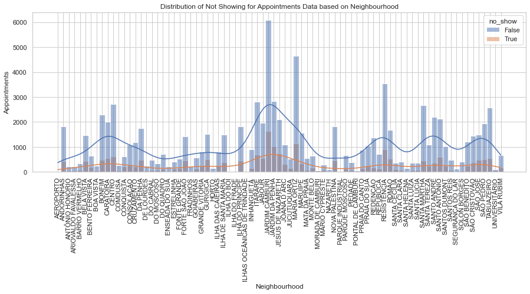

```python
# Displaying the relationship between neighbourhood and not showing up for appointments.
plt.figure(figsize= (15, 5))
sns.histplot(data = df, x = sorted(df['Neighbourhood']), hue= 'no_show', kde= True)
plt.xticks(rotation=90)
plt.title('Distribution of Not Showing for Appointments Data based on Neighbourhood')
plt.xlabel('Neighbourhood')
plt.ylabel('Appointments');

counts = df.groupby(['Neighbourhood', 'no_show']).count()['AppointmentID']
totals = df.groupby('Neighbourhood').count()['AppointmentID']
proportions = (counts / totals)
stats = round(proportions * 100, 2).sort_values(ascending= False)
stats.head(5), stats.iloc[78:84]
```

### Medical History Stats

#### Q3. Are medical history a determinant for not showing up for appointments in Brazil?

```
False    90.17
True      9.83
Name: Scholarship, dtype: float64
```

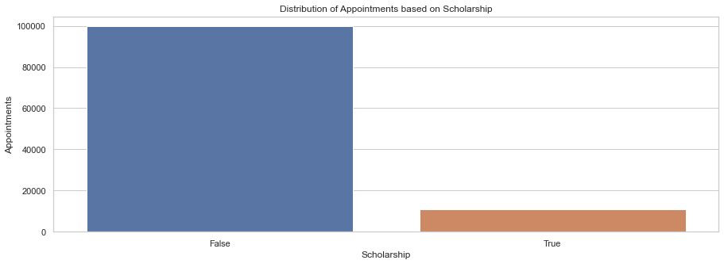

```python
# Displaying appointments count based on scholarship.
counts_figure(df, 'Scholarship', 'Distribution of Appointments based on Scholarship',
              'Scholarship', 'Appointments')

stats = round((df['Scholarship'].value_counts() / df['PatientId'].count() * 100), 2)
stats
```

Data frame shows that 90.17% of appointments were made by non subscribers to the Brazilian welfare program "Bolsa Familia".

[figure not shown]

```
Scholarship  no_show
False        False      80.19
True         False      76.26
             True       23.74
False        True       19.81
Name: AppointmentID, dtype: float64
```

```python
# Displaying the relationship between scholarship and not showing up for appointments.
relation_figure(df, 'Scholarship', 'no_show',
                'Distribution of Not Showing Up based on Gender',
                'Scholarship', 'Appointments')

counts = df.groupby(['Scholarship','no_show']).count()['AppointmentID']
totals = df.groupby('Scholarship').count()['AppointmentID']
proportions = counts / totals
round(proportions * 100, 2).sort_values(ascending= False)
```

```
False    80.28
True     19.72
Name: Hypertension, dtype: float64
```

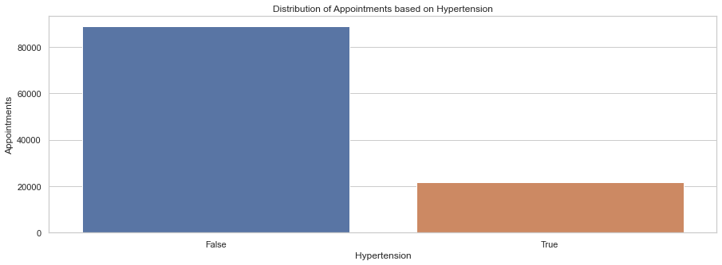

```python
# Displaying appointments count based on hypertension.
counts_figure(df, 'Hypertension', 'Distribution of Appointments based on Hypertension',
              'Hypertension', 'Appointments')

stats = round((df['Hypertension'].value_counts() / df['PatientId'].count() * 100), 2)
stats
```

Data frame shows that 80.28% of appointment were from patients with no history of hypertension.

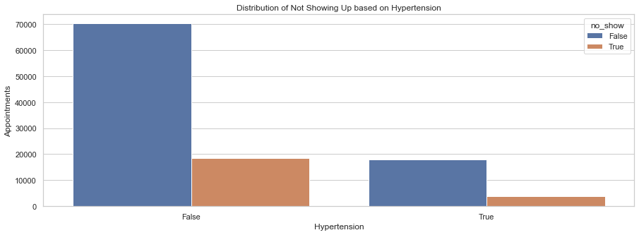

```
Hypertension  no_show
True          False      82.7
False         False      79.1
              True       20.9
True          True       17.3
Name: AppointmentID, dtype: float64
```

```python
# Displaying the relationship between hypertension and not showing up for appointments.
relation_figure(df, 'Hypertension', 'no_show', 'Distribution of Not Showing Up based on Hypertension',
                'Hypertension', 'Appointments')
counts = df.groupby(['Hypertension','no_show']).count()['AppointmentID']
totals = df.groupby('Hypertension').count()['AppointmentID']
proportions = counts / totals
round(proportions * 100, 2).sort_values(ascending= False)
```

Data frame shows that 20.9% of patients with no history of hypertension did not show for their appointments, while 17.3% of patients with history of hypertension did not no show for appointments.

```
False    92.81
True      7.19
Name: Diabetes, dtype: float64
```

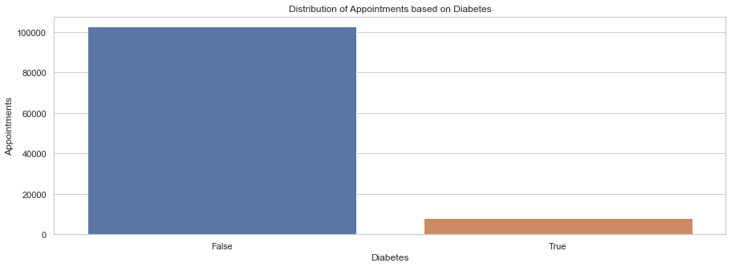

```python
# Displaying appointments count based on diabetes
counts_figure(df, 'Diabetes', 'Distribution of Appointments based on Diabetes',
                'Diabetes', 'Appointments')
stats = round((df['Diabetes'].value_counts() / df['PatientId'].count() * 100), 2)
stats
```

Data frame shows that 92.81% of appointments were from patients with no history of diabetes mellites.

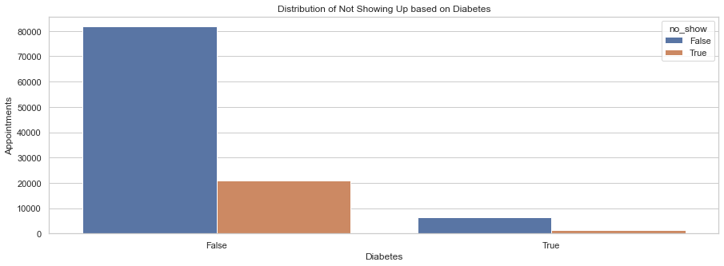

```
Diabetes  no_show
True      False      82.00
False     False      79.64
          True       20.36
True      True       18.00
Name: AppointmentID, dtype: float64
```

```python
# Displaying the relationship between diabetes and not showing up for appointments.
relation_figure(df, 'Diabetes', 'no_show',
                'Distribution of Not Showing Up based on Diabetes',
                'Diabetes', 'Appointments')

counts = df.groupby(['Diabetes','no_show']).count()['AppointmentID']
totals = df.groupby('Diabetes').count()['AppointmentID']
proportions = counts / totals
round(proportions * 100, 2).sort_values(ascending= False)
```

Data frame shows that 20.36% of patients with no history of diabetes do not show for appointment data, while 18% of patients with history of diabetes do not show for their appointments.

```
False    96.96
True      3.04
Name: Alcoholism, dtype: float64
```

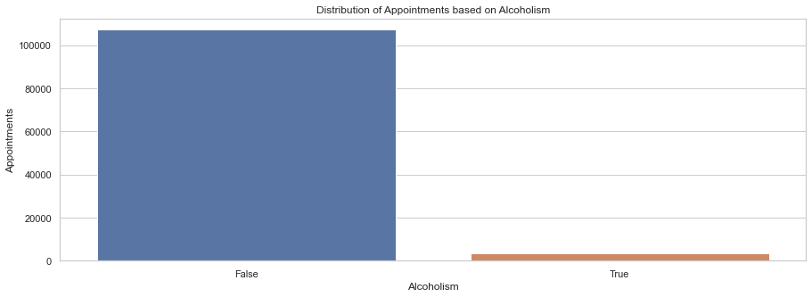

```python
# Displaying appointments count based on alcoholism.
counts_figure(df, 'Alcoholism', 'Distribution of Appointments based on Alcoholism',
              'Alcoholism', 'Appointments')

stats = round((df['Alcoholism'].value_counts() / df['PatientId'].count() * 100), 2)
stats
```

Data frame shows that 96.96% of patients have no history of excessive alcohlol consumption.

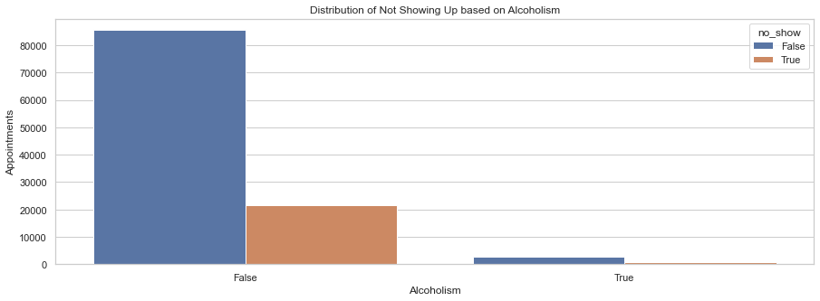

```
Alcoholism  no_show
True        False      79.85
False       False      79.81
            True       20.19
True        True       20.15
Name: AppointmentID, dtype: float64
```

```python
# Displaying the relationship between alcoholism and not showing up for appointments.
relation_figure(df, 'Alcoholism', 'no_show',
                'Distribution of Not Showing Up based on Alcoholism',
                'Alcoholism', 'Appointments')

counts = df.groupby(['Alcoholism','no_show']).count()['AppointmentID']
totals = df.groupby('Alcoholism').count()['AppointmentID']
proportions = counts / totals
round(proportions * 100, 2).sort_values(ascending= False)
```

```
0    97.97
1     1.85
2     0.17
3     0.01
4     0.00
Name: Handicap, dtype: float64
```

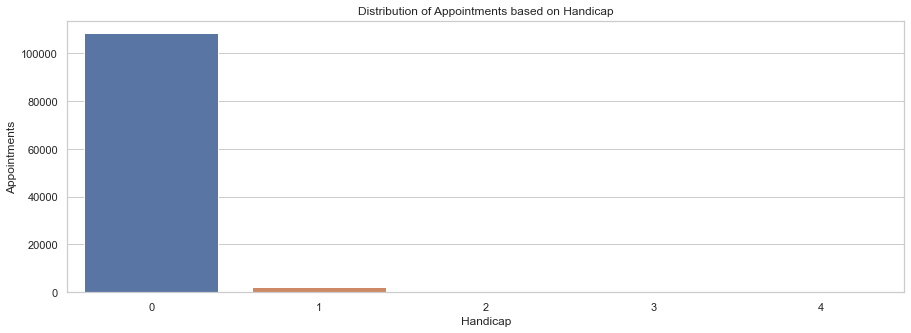

```python
# Displaying appointments count based on disability.
counts_figure(df, 'Handicap', 'Distribution of Appointments based on Handicap',
              'Handicap', 'Appointments')
stats = round((df['Handicap'].value_counts() / df['PatientId'].count() * 100), 2)
stats
```

Data frame shows that 97.97% of patients had no diability of any kind.

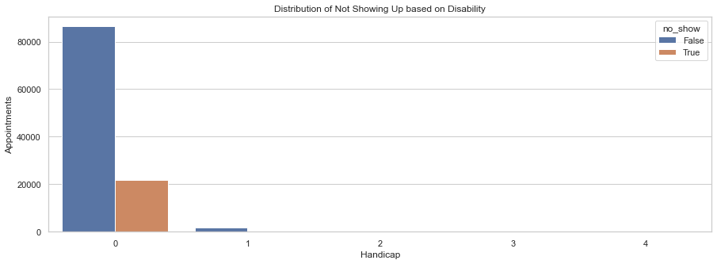

```
Handicap  no_show
1         False      82.08
2         False      79.78
0         False      79.76
3         False      76.92
4         False      66.67
          True       33.33
3         True       23.08
0         True       20.24
2         True       20.22
1         True       17.92
Name: AppointmentID, dtype: float64
```

```python
# Displaying the relationship between disability and not showing up for appointments.
relation_figure(df, 'Handicap', 'no_show',
                'Distribution of Not Showing Up based on Disability',
                'Handicap', 'Appointments')

counts = df.groupby(['Handicap','no_show']).count()['AppointmentID']
totals = df.groupby('Handicap').count()['AppointmentID']
proportions = counts / totals
round(proportions * 100, 2).sort_values(ascending= False)
```

Data frame shows that 33.33% of patients with four types of disabilities (or disability index 4) did not show for their appointments, followed by patients with three types of disabilities (or disability index 3) and people with no disabilities, 23.08% and 20.24% respectively.

#### Q4. Is receiving a reminder SMS for appointments a determinant for showing up for appointments in Brazil?

```
False    67.9
True     32.1
Name: SMS_received, dtype: float64
```

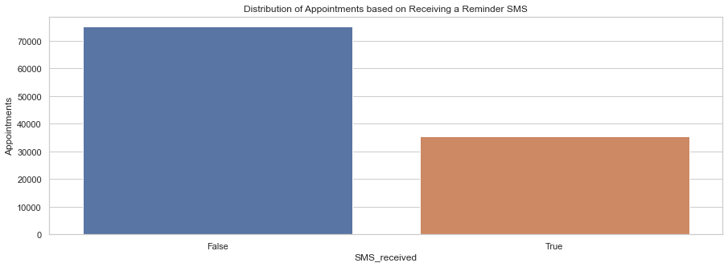

```python
# Displaying appointments count based on receiving a reminder SMS.
counts_figure(df, 'SMS_received',
              'Distribution of Appointments based on Receiving a Reminder SMS',
              'SMS_received', 'Appointments')

stats = round((df['SMS_received'].value_counts() / df['PatientId'].count() * 100), 2)
stats
```

Data frame shows that 67.9% of patients did not receive a reminder SMS before appointments.

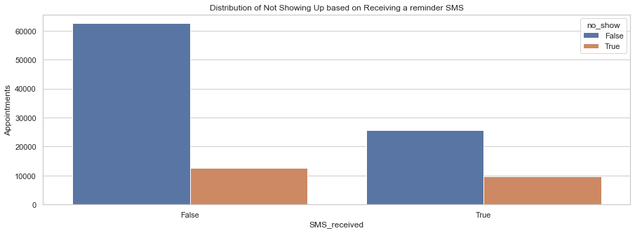

```
SMS_received  no_show
False         False      83.30
True          False      72.43
              True       27.57
False         True       16.70
Name: AppointmentID, dtype: float64
```

```python
# Displaying the relationship between receiving a reminder SMS and not showing up for appointments.
relation_figure(df, 'SMS_received', 'no_show',
                'Distribution of Not Showing Up based on Receiving a reminder SMS',
                'SMS_received', 'Appointments')

counts = df.groupby(['SMS_received','no_show']).count()['AppointmentID']
totals = df.groupby('SMS_received').count()['AppointmentID']
proportions = counts / totals
round(proportions * 100, 2).sort_values(ascending= False)
```